# Loss Reserving Analysis of Workers’ Compensation Claims

ACT 560: Regression Modeling: Insurance

Mobasshira Zaman

04 December 2025

# 1 Executive Summary

This project examines loss reserving for a Workers’ Compensation portfolio using positional data from the CAS NAIC Schedule P database for a single insurer (State Farm Mut Grp). A cumulative incurred loss triangle was constructed for accident years 1988–1997 and analyzed using three standard reserving approaches such as, the deterministic Chain Ladder method, the stochastic Mack Chain-Ladder model, and an over-dispersed Poisson GLM fitted to incremental incurred losses. Diagnostic plots and summary statistics were used to assess development patterns, model fit, and parameter uncertainty.

Results show that Chain Ladder and Mack produce nearly identical total IBNR of about 4400 dollars, which shows that the portfolio is mostly mature with minimal expected future emergence. However, Mack’s wide 95% confidence interval (approximately −58000 to 67000 dollars) and the GLM’s much higher total IBNR estimate (~40000 dollars due to the immature 1997 accident year) shows a uncertainty. Hence, a reasonable strategy is to treat Chain Ladder as a baseline best estimate. Mack or GLM for upper-bound reserves, especially where recent accident years remain less developed is a logical choice.

# 2 Introduction

Loss reserving is a core task in property-casualty insurance, as insurers must hold sufficient reserves to cover future claim payments arising from past policies (Brown & Gottlieb, 2007). For long-tailed lines such as Workers’ Compensation, claims often develop over many years, so actuaries rely on statistical techniques that extrapolate past development patterns into the future. Accurate reserve estimation is essential for financial reporting, pricing, and capital management.

This project analyzes Workers’ Compensation loss development for a single insurer from the Casualty Actuarial Society’s NAIC Schedule P research database (Casualty Actuarial Society, 2011). The primary aim is to construct standard loss development triangles and compare reserve estimates from three approaches such as, the deterministic Chain Ladder method, the stochastic Mack Chain-Ladder model, and a GLM-based reserving model for a selected company (State Farm Mut Grp). By examining the output from each model and comparing their resulting reserve estimates and uncertainty measures, the study illustrates the behavior and assumptions of each method for a relatively mature.

# 3 Data Descripsion

## 3.1 Data Source

The data for this study are sourced from the Casualty Actuarial Society (CAS) Schedule P Loss Reserving Database, which compiles loss development information reported by U.S. insurers to the NAIC. The Workers’ Compensation positional dataset provides detailed accident year and development information for analyzing claim payment patterns (Casualty Actuarial Society, 2011). Resulting triangles represent one company’s experience over 10 accident years and up to 10 development lags.

Table 1 compensation positional dataset” summarizes the key fields used in the analysis. The variables GRCODE and GRNAME identify the insurer, while AccidentYear and DevelopmentYear locate each observation in the loss development grid. DevelopmentLag captures the time since the accident and serves as the development dimension (triangle columns). The main loss and premium variables (IncurLoss_D, CumPaidLoss_D, BulkLoss_D, and the earned premium fields) describe loss experience and exposure. For this project, IncurLoss_D is the primary modeling variable used to construct the cumulative incurred loss triangle. Several other variables (e.g., EarnedPremNet_D, Single) are used only for company selection and filtering; they are not directly modeled.

```r
library(knitr)

data_desc <- data.frame(
  Variable = c("GRCODE","GRNAME","AccidentYear","DevelopmentYear","DevelopmentLag",
               "CumPaidLoss_D","IncurLoss_D","BulkLoss_D",
               "EarnedPremDIR_D","EarnedPremCeded_D","EarnedPremNet_D",
               "PostedReserve97_D","Single"),

  Description = c(
    "NAIC group code identifier for the insurer",
    "Name of insurance company/group",
    "Year in which the loss event occurred",
    "Calendar year of development",
    "Number of years since accident",
    "Cumulative paid losses for Workers’ Compensation",
    "Cumulative incurred losses",
    "Bulk IBNR reserves",
    "Direct earned premium",
    "Ceded earned premium",
    "Net earned premium",
    "Posted reserve as of 1997",
    "Indicator if entity is individual (1) or group (0)"
  ),

  Role = c(
    "Identifies company/group",
    "Label only",
    "Triangle origin (i)",
    "Informational",
    "Triangle column (j)",
    "Not used in this project",
    "Primary modeling variable",
    "Not used",
    "Context only",
    "Context only",
    "Used for company selection only",
    "Informational",
    "Used for filtering"
  )
)

kable(data_desc, caption = "Table 1: Variable definitions for the workers’ compensation positional dataset")
```

Table 1: Variable definitions for the workers’ compensation positional dataset

| Variable | Description | Role |
| --- | --- | --- |
| GRCODE | NAIC group code identifier for the insurer | Identifies company/group |
| GRNAME | Name of insurance company/group | Label only |
| AccidentYear | Year in which the loss event occurred | Triangle origin (i) |
| DevelopmentYear | Calendar year of development | Informational |
| DevelopmentLag | Number of years since accident | Triangle column (j) |
| CumPaidLoss_D | Cumulative paid losses for Workers’ Compensation | Not used in this project |
| IncurLoss_D | Cumulative incurred losses | Primary modeling variable |
| BulkLoss_D | Bulk IBNR reserves | Not used |
| EarnedPremDIR_D | Direct earned premium | Context only |
| EarnedPremCeded_D | Ceded earned premium | Context only |
| EarnedPremNet_D | Net earned premium | Used for company selection only |
| PostedReserve97_D | Posted reserve as of 1997 | Informational |
| Single | Indicator if entity is individual (1) or group (0) | Used for filtering |

## 3.2 Exploratory Data Analysis

The dataset contains 13,200 observations and 13 variables, confirming that the positional file is fairly large and covers multiple insurers and years. The group identifier GRCODE is numeric, GRNAME is character, and the accident and development years are recorded as numeric year values. AccidentYear ranges from 1988 to 1997, giving 10 accident years. DevelopmentYear ranges from 1988 to 2006, corresponding to up to 10 years of development for the earliest accident year. IncurLoss_D can take small negative values, which may correspond to adjustments or corrections in reported losses.

```r
# =========================
# LIBRARIES
# =========================
library(knitr)
library(dplyr)
library(ggplot2)
library(tidyr)
library(ChainLadder)
library(readxl)
library(e1071)
library(kableExtra)

# =========================
# LOAD DATA
# =========================
df <- as.data.frame(read_excel("/Users/mobasshirazaman/Library/CloudStorage/OneDrive-NorthernIllinoisUniversity/ASU/Fall2025/ACT560/Project2/wkcomp_pos.xlsx"))

str(df)
```

```
## 'data.frame':    13200 obs. of  13 variables:
##  $ GRCODE           : num  86 86 86 86 86 86 86 86 86 86 ...
##  $ GRNAME           : chr  "Allstate Ins Co Grp" "Allstate Ins Co Grp" "Allstate Ins Co Grp" "Allstate Ins Co Grp" ...
##  $ AccidentYear     : num  1988 1988 1988 1988 1988 ...
##  $ DevelopmentYear  : num  1988 1989 1990 1991 1992 ...
##  $ DevelopmentLag   : num  1 2 3 4 5 6 7 8 9 10 ...
##  $ IncurLoss_D      : num  367404 362988 347288 330648 354690 ...
##  $ CumPaidLoss_D    : num  70571 155905 220744 251595 274156 ...
##  $ BulkLoss_D       : num  127737 60173 27763 15280 27689 ...
##  $ EarnedPremDIR_D  : num  400699 400699 400699 400699 400699 ...
##  $ EarnedPremCeded_D: num  5957 5957 5957 5957 5957 ...
##  $ EarnedPremNet_D  : num  394742 394742 394742 394742 394742 ...
##  $ Single           : num  0 0 0 0 0 0 0 0 0 0 ...
##  $ PostedReserve97_D: num  281872 281872 281872 281872 281872 ...
```

```r
summary(df)
```

```
##      GRCODE         GRNAME           AccidentYear  DevelopmentYear
##  Min.   :   86   Length:13200       Min.   :1988   Min.   :1988
##  1st Qu.: 8526   Class :character   1st Qu.:1990   1st Qu.:1994
##  Median :14110   Mode  :character   Median :1992   Median :1997
##  Mean   :17153                      Mean   :1992   Mean   :1997
##  3rd Qu.:26983                      3rd Qu.:1995   3rd Qu.:2000
##  Max.   :44300                      Max.   :1997   Max.   :2006
##  DevelopmentLag  IncurLoss_D     CumPaidLoss_D        BulkLoss_D
##  Min.   : 1.0   Min.   :   -59   Min.   :  -338.0   Min.   : -4621.0
##  1st Qu.: 3.0   1st Qu.:     0   1st Qu.:     0.0   1st Qu.:     0.0
##  Median : 5.5   Median :   544   Median :   351.5   Median :     5.0
##  Mean   : 5.5   Mean   : 11532   Mean   :  8215.7   Mean   :  1570.1
##  3rd Qu.: 8.0   3rd Qu.:  6526   3rd Qu.:  4565.0   3rd Qu.:   259.2
##  Max.   :10.0   Max.   :367404   Max.   :325322.0   Max.   :145296.0
##  EarnedPremDIR_D  EarnedPremCeded_D EarnedPremNet_D      Single
##  Min.   : -6518   Min.   :-3522.0   Min.   : -9731   Min.   :0.0000
##  1st Qu.:     0   1st Qu.:    0.0   1st Qu.:     0   1st Qu.:0.0000
##  Median :  1419   Median :  144.5   Median :   827   Median :1.0000
##  Mean   : 18438   Mean   : 1812.3   Mean   : 16626   Mean   :0.7273
##  3rd Qu.: 11354   3rd Qu.: 1141.0   3rd Qu.:  9180   3rd Qu.:1.0000
##  Max.   :421223   Max.   :78730.0   Max.   :418755   Max.   :1.0000
##  PostedReserve97_D
##  Min.   :      0
##  1st Qu.:    411
##  Median :   2732
##  Mean   :  39714
##  3rd Qu.:  19266
##  Max.   :1090093
```

The missing-value and cardinality summary shows that there are no missing values in any of the variables used in the project, which simplifies the construction of triangles and the fitting of models. The cardinality counts confirm that there are 132 distinct insurer groups (GRCODE and GRNAME), 10 accident years and 10 development lags appear, and the primary loss variable IncurLoss_D has 5,899 distinct values, reflecting substantial variation in incurred amounts.Because there are no NA values, no imputation or data cleaning is needed before forming the loss development triangles.

```r
# =========================
# MISSING VALUES & CARDINALITY
# =========================
summary_table <- data.frame(
  Missing_Values = colSums(is.na(df)),
  Cardinality = sapply(df, function(x) length(unique(x)))
)

kable(summary_table,  caption = "Table 2: Missing values and cardinality checking for data.")
```

Table 2: Missing values and cardinality checking for data.

|  | Missing_Values | Cardinality |
| --- | --- | --- |
| GRCODE | 0 | 132 |
| GRNAME | 0 | 132 |
| AccidentYear | 0 | 10 |
| DevelopmentYear | 0 | 19 |
| DevelopmentLag | 0 | 10 |
| IncurLoss_D | 0 | 5899 |
| CumPaidLoss_D | 0 | 5435 |
| BulkLoss_D | 0 | 2654 |
| EarnedPremDIR_D | 0 | 907 |
| EarnedPremCeded_D | 0 | 722 |
| EarnedPremNet_D | 0 | 898 |
| Single | 0 | 2 |
| PostedReserve97_D | 0 | 121 |

The bar plot of the top 20 companies by total latest incurred loss highlights large differences in portfolio size across insurer groups. A few companies account for much larger totals, suggesting they write significantly more Workers’ Compensation business. For this project, a single company (here, “State Farm Mut Grp”) is selected for detailed analysis. This choice provides a relatively large and stable triangle for that insurer, while keeping the modeling focused on one homogeneous rather than aggregating multiple companies.

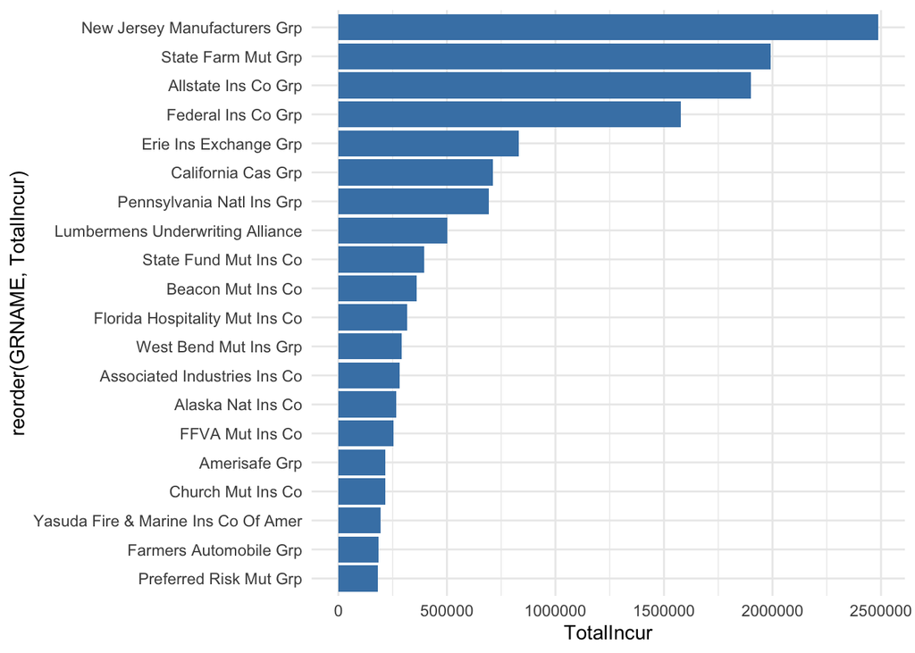

```r
# =========================
# TOP 20 COMPANIES BARPLOT
# =========================
incur_latest <- df %>%
  group_by(GRCODE, GRNAME, AccidentYear) %>%
  summarise(IncurLatest = max(IncurLoss_D, na.rm = TRUE), .groups = "drop")

company_total <- incur_latest %>%
  group_by(GRCODE, GRNAME) %>%
  summarise(TotalIncur = sum(IncurLatest, na.rm = TRUE), .groups = "drop") %>%
  arrange(desc(TotalIncur)) %>%
  slice_head(n = 20)

ggplot(company_total,
       aes(x = reorder(GRNAME, TotalIncur), y = TotalIncur)) +
  geom_col(fill = "steelblue") +
  coord_flip() +
  theme_minimal()
```

Figure 1: Companies with the highest total incur loss.

## 3.3 Data Pre-porcessing

Data was filtered for only State Farm Mut Grp and the filtered data has accident years from 1988 to 1997 (10 years). Incurred losses rise from ~128K in 1988 to over 250K in the early 1990s before declining toward ~130K by 1997. Older years show left-skewed development (losses mostly recognized early), whereas recent years are more symmetric, indicating continuing development.

Table 3: Desceriptive Statistics for State farm Mut Grp

```r
# =========================
# FILTER NJM DATA
# =========================
njm_incur <- df %>%
  filter(GRNAME == "State Farm Mut Grp") %>%
  select(AccidentYear, DevelopmentLag, IncurLoss_D)

# =========================
# DESCRIPTIVE STATISTICS TABLE
# =========================
njm_year_stats <- njm_incur %>%
  group_by(AccidentYear) %>%
  summarise(
    Mean = mean(IncurLoss_D, na.rm = TRUE),
    StdDev = sd(IncurLoss_D, na.rm = TRUE),
    Min = min(IncurLoss_D, na.rm = TRUE),
    Max = max(IncurLoss_D, na.rm = TRUE),
    Median = median(IncurLoss_D, na.rm = TRUE),
    SampleSize = sum(!is.na(IncurLoss_D)),
    Skewness = e1071::skewness(IncurLoss_D, na.rm = TRUE, type = 2),
    .groups = "drop"
  ) %>%
  mutate(AccidentYear = as.character(AccidentYear))

njm_overall <- njm_incur %>%
  summarise(
    AccidentYear = "All",
    Mean = mean(IncurLoss_D, na.rm = TRUE),
    StdDev = sd(IncurLoss_D, na.rm = TRUE),
    Min = min(IncurLoss_D, na.rm = TRUE),
    Max = max(IncurLoss_D, na.rm = TRUE),
    Median = median(IncurLoss_D, na.rm = TRUE),
    SampleSize = sum(!is.na(IncurLoss_D)),
    Skewness = e1071::skewness(IncurLoss_D, na.rm = TRUE, type = 2)
  )


njm_table1 <- bind_rows(njm_year_stats, njm_overall)

# Display
kable(njm_table1)
```

| AccidentYear | Mean | StdDev | Min | Max | Median | SampleSize | Skewness |
| --- | --- | --- | --- | --- | --- | --- | --- |
| 1988 | 127949.9 | 13371.735 | 91892 | 134401 | 133656.5 | 10 | -2.6601310 |
| 1989 | 157738.2 | 14200.045 | 117540 | 164650 | 161754.5 | 10 | -3.0991500 |
| 1990 | 204406.3 | 17167.144 | 155671 | 211660 | 209368.0 | 10 | -3.1323134 |
| 1991 | 242587.3 | 19035.351 | 189021 | 253292 | 248353.0 | 10 | -3.0304386 |
| 1992 | 257564.1 | 14913.741 | 229435 | 289785 | 256213.0 | 10 | 0.5095708 |
| 1993 | 250698.0 | 4006.286 | 245594 | 259975 | 251025.0 | 10 | 1.2894496 |
| 1994 | 207316.7 | 3774.794 | 200624 | 212555 | 207534.0 | 10 | -0.3096862 |
| 1995 | 173397.3 | 4261.094 | 169122 | 181175 | 172083.0 | 10 | 0.7586153 |
| 1996 | 141442.0 | 4100.733 | 137267 | 151415 | 140401.5 | 10 | 1.7447608 |
| 1997 | 130087.3 | 3699.365 | 125429 | 134218 | 129726.0 | 10 | 0.0222008 |
| All | 189318.7 | 49068.532 | 91892 | 289785 | 179806.0 | 100 | 0.1271675 |

The heatmap shows losses increasing quickly in early development and stabilizing for older accident years. The latest years remain less developed and drive remaining IBNR. Overall, the triangle is mature with limited future growth expected.

```r
library(dplyr)
library(ChainLadder)

# =========================
# CREATE CUMULATIVE TRIANGLE
# =========================
library(dplyr)
library(ChainLadder)

# Use only this filtered NJM data
njm_incur <- df %>%
  filter(GRNAME == "State Farm Mut Grp") %>%
  select(AccidentYear, DevelopmentLag, IncurLoss_D)

min_ay  <- min(njm_incur$AccidentYear)
max_lag <- max(njm_incur$DevelopmentLag)

njm_incur_tri <- njm_incur %>%
  # keep only the upper-left triangle:
  # AY = min_ay     -> lags 1..10
  # AY = min_ay+1   -> lags 1..9
  # ...
  # AY = min_ay+9   -> lag 1 only
  filter(DevelopmentLag <= max_lag - (AccidentYear - min_ay)) %>%
  arrange(AccidentYear, DevelopmentLag)

incur_cum_triangle <- as.triangle(
  njm_incur_tri,
  origin = "AccidentYear",
  dev    = "DevelopmentLag",
  value  = "IncurLoss_D"
)

# incur_cum_triangle
```

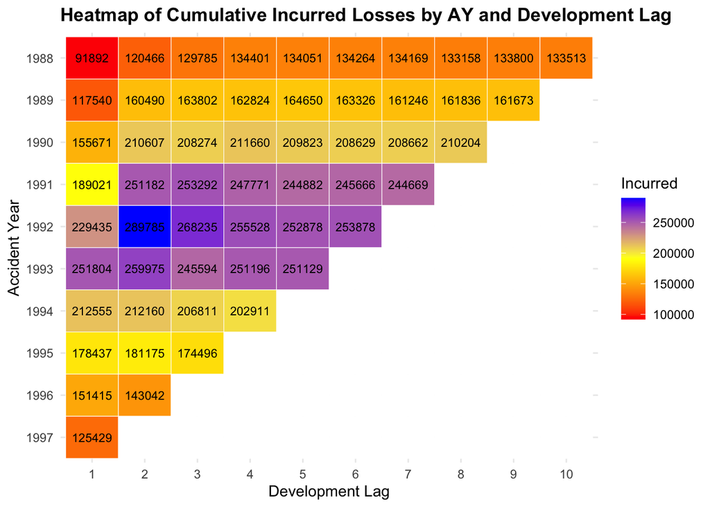

Figure 2: Heatmap of Cumulative Incurred Losses by AY and Development Lag.

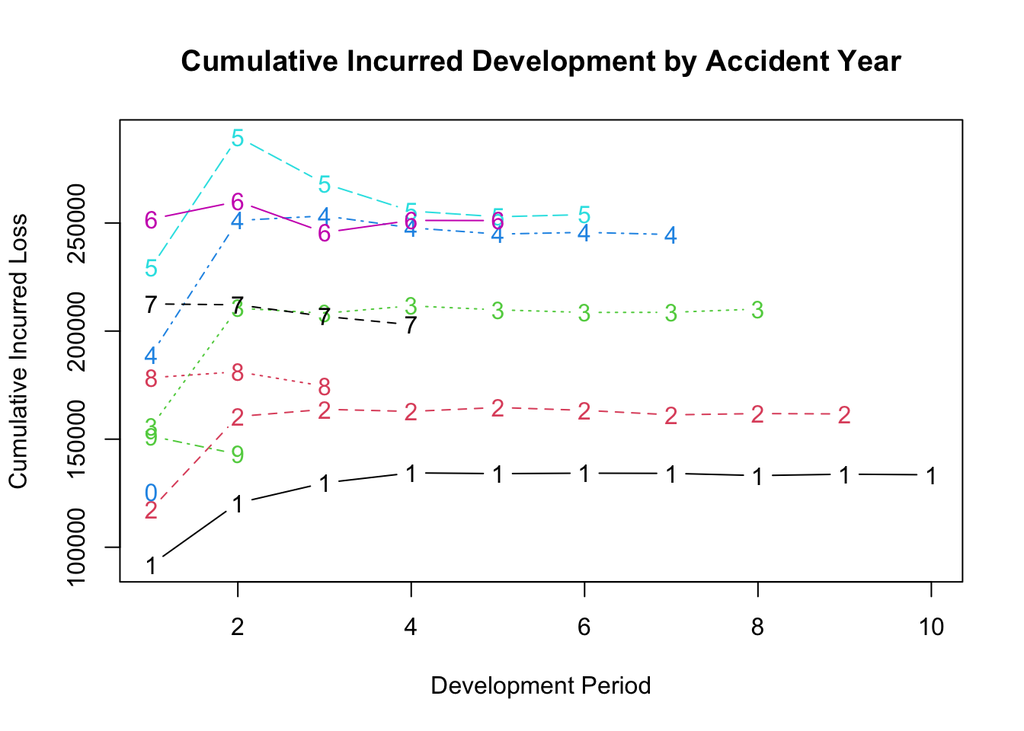

```r
plot(incur_cum_triangle,
     main = "Cumulative Incurred Development by Accident Year",
     xlab = "Development Period",
     ylab = "Cumulative Incurred Loss")
```

Figure 3: Cumulative Incurred Development by Accident Year

Each panel shows cumulative incurred losses by accident year, with older years flattening quickly, indicating they are near ultimate values. Recent years have shorter, incomplete curves, reflecting greater uncertainty and remaining development.

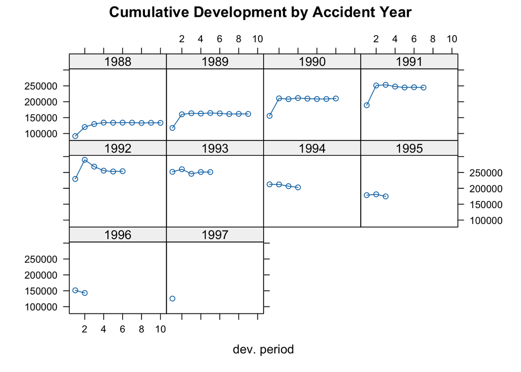

```r
plot(incur_cum_triangle,
     lattice = TRUE,
     main = "Cumulative Development by Accident Year")
```

Figure 4: Cumulative Development by Accident Year

# 4 Method

## 4.1 Chain Ladder model

The Chain Ladder model projects ultimates using historical development factors from the cumulative triangle. Most accident years show very small or even negative IBNR, indicating minimal expected future development and some potential redundancy. Only 1997 shows notable reserve (~14,890) due to limited maturity. Overall IBNR is low (~4,450), consistent with a largely run-off and stable.

```r
# =========================
# CHAIN LADDER MODEL
# =========================
# 1. Fit Chain Ladder factors
cl_mod <- chainladder(incur_cum_triangle)

# 2. Get the completed cumulative triangle (projected to ultimate)
cl_full_triangle <- predict(cl_mod)   # completed cum triangle

# 3. Latest observed cumulative losses (from original data)
cl_latest <- getLatestCumulative(incur_cum_triangle)

# 4. Ultimate losses from completed triangle
cl_ultimate <- getLatestCumulative(cl_full_triangle)

# 5. IBNR by accident year
cl_reserve <- cl_ultimate - cl_latest

# 6. Total IBNR (this is the real Chain Ladder reserve)
cl_total_reserve <- sum(cl_reserve)

cl_reserve        # AY-level reserves
```

```
##       1988       1989       1990       1991       1992       1993       1994
##     0.0000  -346.7874  -110.2969   415.4446  -630.6186  -753.4884 -1564.2972
##       1995       1996       1997
## -2460.0818 -4990.5799 14890.2504
## attr(,"latestcol")
## 1988 1989 1990 1991 1992 1993 1994 1995 1996 1997
##   10   10   10   10   10   10   10   10   10   10
## attr(,"rowsname")
## [1] "origin"
## attr(,"colnames")
##  [1] "10" "10" "10" "10" "10" "10" "10" "10" "10" "10"
## attr(,"colsname")
## [1] "dev"
```

```r
cl_total_reserve  # total reserve
```

```
## [1] 4449.545
```

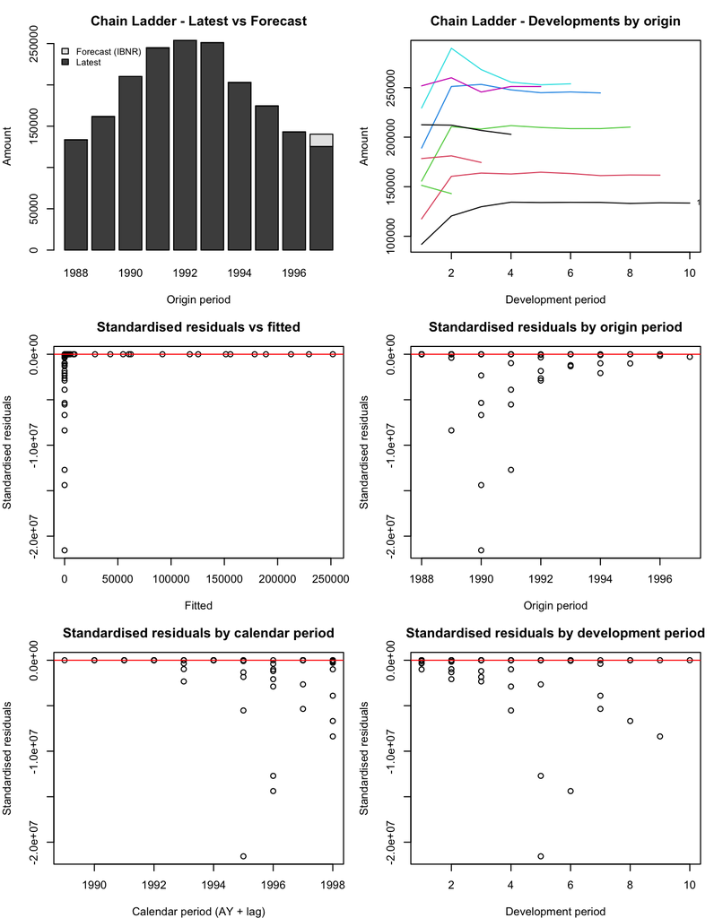

```r
# Incremental observed and fitted for Chain Ladder
cl_inc_obs <- cum2incr(incur_cum_triangle)
cl_inc_fit <- cum2incr(cl_full_triangle)

# Make sure row/col names are numeric for plotting
rownames(incur_cum_triangle) <- as.numeric(rownames(incur_cum_triangle))
colnames(incur_cum_triangle) <- as.numeric(colnames(incur_cum_triangle))
rownames(cl_inc_obs)         <- rownames(incur_cum_triangle)
colnames(cl_inc_obs)         <- colnames(incur_cum_triangle)
rownames(cl_inc_fit)         <- rownames(incur_cum_triangle)
colnames(cl_inc_fit)         <- colnames(incur_cum_triangle)

plot_reserving_diagnostics(
  method_name  = "Chain Ladder",
  latest_vec   = cl_latest,
  ultimate_vec = cl_ultimate,
  cum_triangle = incur_cum_triangle,
  inc_obs      = cl_inc_obs,
  inc_fit      = cl_inc_fit
)
```

Figure 5: Chain Ladder diagnostics showing development fit and standardized residual patterns.

## 4.2 Mack Chain-Ladder model

The Mack Chain-Ladder model produces ultimate and IBNR estimates nearly identical to the deterministic Chain Ladder, with total IBNR of about 4,450. Its main contribution is the standard error and uncertainty measure — the total IBNR S.E. is ~31,966, giving a wide 95% CI of approximately [−58,205, 67,104]. This wide interval indicates high uncertainty relative to the small reserve estimate, typical for mature triangles where only the latest accident year has meaningful remaining development.

```r
# =========================
# MACK MODEL
# =========================

# 1. Fit Mack Chain-Ladder model (stochastic version of chain ladder)
mack_mod <- MackChainLadder(
  incur_cum_triangle,
  est.sigma = "Mack"
)

# 2. AY-level results from summary (this part was already working)
mack_sum      <- summary(mack_mod)
mack_byorigin <- as.data.frame(mack_sum$ByOrigin)

# Ultimate and IBNR by accident year
mack_ultimate <- mack_byorigin[, "Ultimate"]
mack_reserve  <- mack_byorigin[, "IBNR"]

# 3. Total IBNR (just sum the AY IBNR)
mack_total_reserve <- sum(mack_reserve)

# 4. Standard error of TOTAL IBNR comes straight from the Mack object
#    (this is the scalar you actually want, not the big matrix)
mack_total_se <- as.numeric(mack_mod$Total.Mack.S.E)

# 5. 95% CI for total IBNR (optional but nice)
mack_total_lower95 <- mack_total_reserve - 1.96 * mack_total_se
mack_total_upper95 <- mack_total_reserve + 1.96 * mack_total_se

# Quick checks in console
mack_ultimate        # AY-level ultimate
```

```
##  [1] 133513.0 161326.2 210093.7 245084.4 253247.4 250375.5 201346.7 172035.9
##  [9] 138051.4 140319.3
```

```r
mack_reserve         # AY-level IBNR (should match cl_reserve)
```

```
##  [1]     0.0000  -346.7874  -110.2969   415.4446  -630.6186  -753.4884
##  [7] -1564.2972 -2460.0818 -4990.5799 14890.2504
```

```r
mack_total_reserve   # scalar total IBNR
```

```
## [1] 4449.545
```

```r
mack_total_se        # scalar SE for total IBNR
```

```
## [1] 31966.43
```

```r
mack_total_lower95
```

```
## [1] -58204.66
```

```r
mack_total_upper95
```

```
## [1] 67103.75
```

```r
#mack_byorigin[,"Mack.S.E"]
```

Each panel shows incurred loss development for accident years, with Mack’s dotted line representing uncertainty. Older years flatten early, while younger years (1996–1997) still develop, driving most future IBNR. Hence, Chain Ladder and Mack produce small total reserves, but still require caution around recent years.

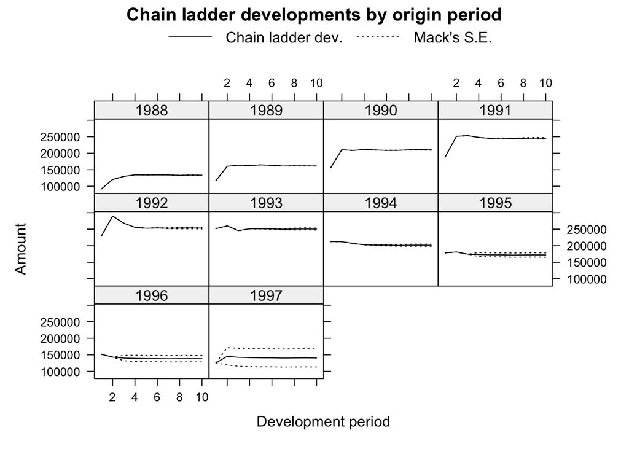

```r
plot(mack_mod, lattice = TRUE)
```

Figure 6: Chain Ladder & Mack Development by Origin Year

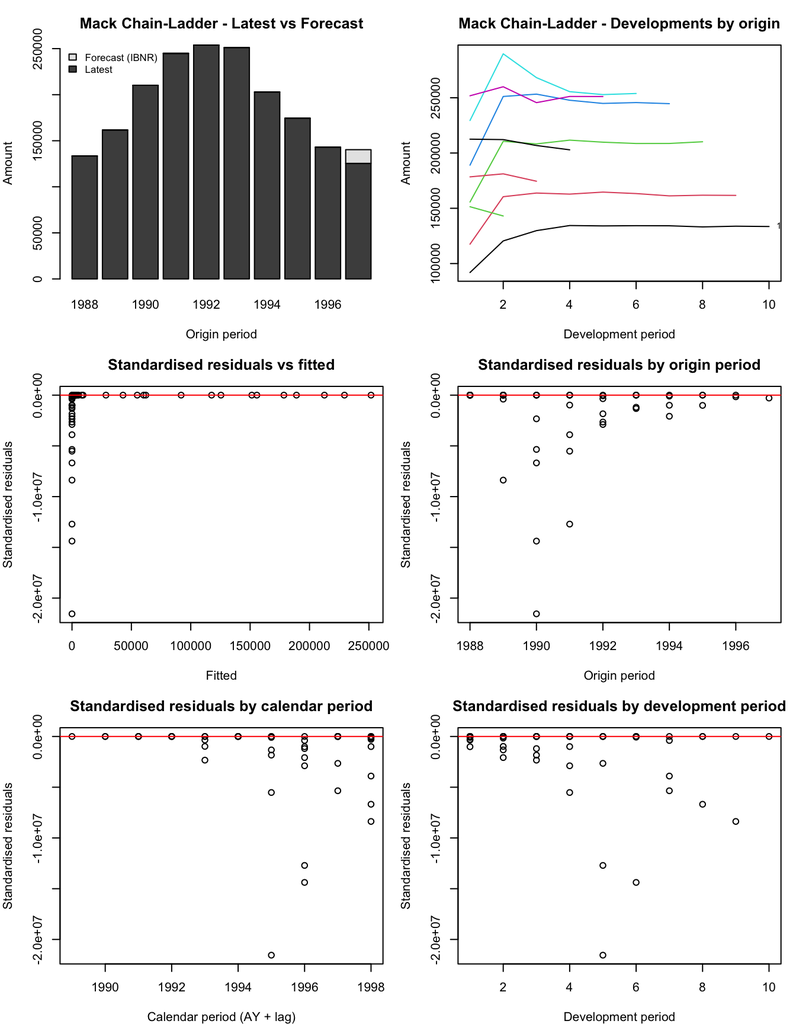

```r
# Latest cumulative for Mack = Ultimate - IBNR
mack_latest <- mack_ultimate - mack_reserve
names(mack_latest) <- rownames(mack_byorigin)
names(mack_ultimate) <- rownames(mack_byorigin)

# Use the same cumulative and incremental triangles as Chain Ladder
mack_inc_obs <- cum2incr(incur_cum_triangle)
mack_inc_fit <- cum2incr(predict(cl_mod))

rownames(mack_inc_obs) <- rownames(incur_cum_triangle)
colnames(mack_inc_obs) <- colnames(incur_cum_triangle)
rownames(mack_inc_fit) <- rownames(incur_cum_triangle)
colnames(mack_inc_fit) <- colnames(incur_cum_triangle)

plot_reserving_diagnostics(
  method_name  = "Mack Chain-Ladder",
  latest_vec   = mack_latest,
  ultimate_vec = mack_ultimate,
  cum_triangle = incur_cum_triangle,
  inc_obs      = mack_inc_obs,
  inc_fit      = mack_inc_fit
)
```

Figure 7: Mack Chain-Ladder Diagnostic Plots

## 4.3 Generalized Linear Model

The GLM (ODP) model estimates a much higher total IBNR (~40,375) driven mainly by the immature accident year 1997. Compared to Chain Ladder or Mack Chain Ladder (~4,450) this is heavy amount. The mdoel incorporates over-dispersion and parametric structure, leading to more conservative future development expectations. The standard error is large, indicating substantial uncertainty, but results still suggest a mostly mature portfolio with risk concentrated in the youngest year.

```r
# =========================
# GLM RESERVE MODEL
# =========================

library(ChainLadder)

# # Convert cumulative triangle to incremental
# glm_triangle <- cum2incr(incur_cum_triangle)
#
# # GLM cannot handle zero / negative values
# glm_triangle_adj <- glm_triangle
# glm_triangle_adj[
#   !is.na(glm_triangle_adj) & glm_triangle_adj <= 0
# ] <- 1e-6



# Convert cumulative triangle to incremental
glm_triangle <- cum2incr(incur_cum_triangle)

# GLM cannot handle zero / negative values
glm_triangle_adj <- glm_triangle
glm_triangle_adj[!is.na(glm_triangle_adj) & glm_triangle_adj <= 0] <- 1e-6

# Make sure it's a proper 'triangle' object
glm_triangle_adj <- as.triangle(glm_triangle_adj)

set.seed(123)

# =========================
# GLM with OVER-DISPERSED POISSON
# =========================
glm_mod <- glmReserve(
  triangle   = glm_triangle_adj,
  var.power  = 1,      # over-dispersed Poisson
  link.power = 0,      # log link
  cum        = FALSE,
  # mse.method = "formula"
)


glm_sum <- summary(glm_mod)
```

```
##        Latest Dev.To.Date Ultimate  IBNR          S.E        CV
## 1989   166218   1.0000000   166218     0 1.536266e-01       Inf
## 1990   215568   0.9978706   216028   460 2.611264e+03 5.6766605
## 1991   254076   0.9937499   255674  1598 4.728877e+03 2.9592471
## 1992   290785   0.9937087   292626  1841 5.210759e+03 2.8303960
## 1993   265577   0.9918361   267763  2186 5.428008e+03 2.4830776
## 1994   212555   0.9904660   214601  2046 4.993969e+03 2.4408449
## 1995   181175   0.9816804   184556  3381 6.055800e+03 1.7911270
## 1996   151415   0.9731729   155589  4174 6.557557e+03 1.5710486
## 1997   125429   0.8355472   150116 24687 1.666158e+04 0.6749129
## total 1862798   0.9787854  1903173 40375 2.809351e+04 0.6958145
```

```r
glm_df <- glm_mod$summary

glm_df
```

|  | Latest | Dev.To.Date | Ultimate | IBNR | S.E | CV |
| --- | --- | --- | --- | --- | --- | --- |
| 1989 | 166218 | 1.0000000 | 166218 | 0 | 1.536266e-01 | Inf |
| 1990 | 215568 | 0.9978706 | 216028 | 460 | 2.611264e+03 | 5.6766605 |
| 1991 | 254076 | 0.9937499 | 255674 | 1598 | 4.728877e+03 | 2.9592471 |
| 1992 | 290785 | 0.9937087 | 292626 | 1841 | 5.210759e+03 | 2.8303960 |
| 1993 | 265577 | 0.9918361 | 267763 | 2186 | 5.428008e+03 | 2.4830776 |
| 1994 | 212555 | 0.9904660 | 214601 | 2046 | 4.993969e+03 | 2.4408449 |
| 1995 | 181175 | 0.9816804 | 184556 | 3381 | 6.055800e+03 | 1.7911270 |
| 1996 | 151415 | 0.9731729 | 155589 | 4174 | 6.557557e+03 | 1.5710486 |
| 1997 | 125429 | 0.8355472 | 150116 | 24687 | 1.666158e+04 | 0.6749129 |
| total | 1862798 | 0.9787854 | 1903173 | 40375 | 2.809351e+04 | 0.6958145 |

```r
# 2) Split AY rows vs total row
glm_ay     <- glm_df[rownames(glm_df) != "total", , drop = FALSE]
glm_totals <- glm_df[rownames(glm_df) == "total", , drop = FALSE]

# 3) AY-level Ultimate and Reserve (IBNR)
glm_ultimate <- glm_ay$Ultimate
glm_reserve  <- glm_ay$IBNR

# 4) Total reserve and its standard error
glm_total_reserve <- glm_totals$IBNR
glm_total_se      <- glm_totals$S.E
glm_ay_se <- glm_ay$S.E

# Quick checks
# glm_ay_se
glm_ultimate
```

```
## [1] 166218 216028 255674 292626 267763 214601 184556 155589 150116
```

```r
glm_reserve
```

```
## [1]     0   460  1598  1841  2186  2046  3381  4174 24687
```

```r
glm_total_reserve
```

```
## [1] 40375
```

```r
glm_total_se
```

```
## [1] 28093.51
```

Loss development drops sharply after the first few periods across all accident years, indicating fast reporting and little late development, with 1997 still partially immature.

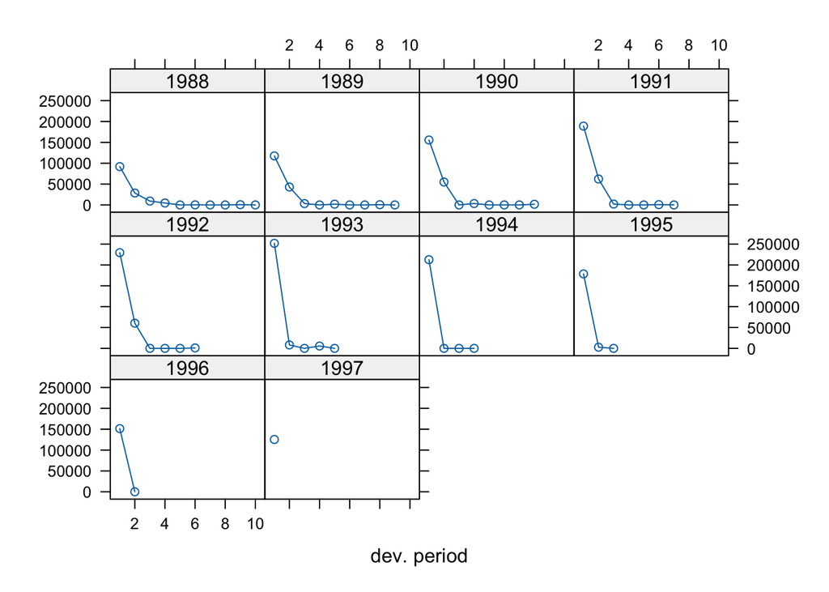

```r
plot(glm_mod, lattice = TRUE)
```

Figure 8: GLM Incremental Development Plot

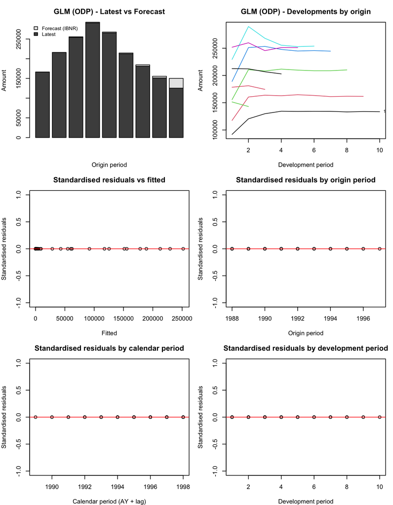

```r
# =========================
# GLM DIAGNOSTIC PLOTS (using FullTriangle)
# =========================

# 0) Local matrix copies
cum_mat <- as.matrix(incur_cum_triangle)
inc_obs <- as.matrix(glm_triangle_adj)
inc_fit <- as.matrix(glm_mod$FullTriangle)

# Sanity checks
stopifnot(all(dim(cum_mat) == dim(inc_obs)))
stopifnot(all(dim(cum_mat) == dim(inc_fit)))

n_origin <- nrow(cum_mat)
n_dev    <- ncol(cum_mat)

# 1) Origin and development indices
origin_years <- suppressWarnings(as.numeric(rownames(cum_mat)))
if (any(is.na(origin_years))) {
  origin_years <- seq_len(n_origin)
}

dev_lags <- suppressWarnings(as.numeric(colnames(cum_mat)))
if (any(is.na(dev_lags))) {
  dev_lags <- seq_len(n_dev)
}

# Put consistent dimnames on our local matrices
rownames(cum_mat) <- origin_years
colnames(cum_mat) <- dev_lags
rownames(inc_obs) <- origin_years
colnames(inc_obs) <- dev_lags
rownames(inc_fit) <- origin_years
colnames(inc_fit) <- dev_lags

# 2) Build origin / dev / calendar matrices
origin_mat <- matrix(rep(origin_years, each = n_dev),
                     nrow = n_origin, ncol = n_dev)
dev_mat    <- matrix(rep(dev_lags,     times = n_origin),
                     nrow = n_origin, ncol = n_dev)
cal_mat    <- origin_mat + dev_mat  # simple calendar index

# 3) Standardised residuals: (obs - fit)/sqrt(fit)
inc_fit_pos <- pmax(inc_fit, 1e-6)  # avoid zero
resid_mat   <- (inc_obs - inc_fit_pos) / sqrt(inc_fit_pos)

keep <- !is.na(inc_obs)

resid_vec  <- resid_mat[keep]
fitted_vec <- inc_fit_pos[keep]
origin_vec <- origin_mat[keep]
dev_vec    <- dev_mat[keep]
cal_vec    <- cal_mat[keep]

# 4) Latest and Ultimate by AY from GLM summary
glm_df <- glm_mod$summary
glm_ay <- glm_df[rownames(glm_df) != "total", , drop = FALSE]

glm_latest   <- glm_ay[, "Latest"]
glm_ultimate <- glm_ay[, "Ultimate"]

ibnr_vec <- glm_ultimate - glm_latest
bar_mat  <- rbind(Latest   = glm_latest,
                  Forecast = pmax(ibnr_vec, 0))

# 5) 6-panel plot
op <- par(mfrow = c(3, 2), mar = c(4, 4, 3, 1))

## (1) Barplot: Latest vs Forecast (IBNR)
barplot(bar_mat,
        beside      = FALSE,
        main        = "GLM (ODP) - Latest vs Forecast",
        ylab        = "Amount",
        xlab        = "Origin period",
        legend.text = c("Latest", "Forecast (IBNR)"),
        args.legend = list(x = "topleft", bty = "n", cex = 0.8))

## (2) Development curves (cumulative)
matplot(dev_lags, t(cum_mat),
        type = "l", lty = 1,
        main = "GLM (ODP) - Developments by origin",
        xlab = "Development period", ylab = "Amount")
text(x      = max(dev_lags),
     y      = cum_mat[, ncol(cum_mat)],
     labels = origin_years, pos = 4, cex = 0.7)

## (3) Residuals vs fitted
plot(fitted_vec, resid_vec,
     main = "Standardised residuals vs fitted",
     xlab = "Fitted", ylab = "Standardised residuals")
abline(h = 0, col = "red")

## (4) Residuals vs origin
plot(origin_vec, resid_vec,
     main = "Standardised residuals by origin period",
     xlab = "Origin period", ylab = "Standardised residuals")
abline(h = 0, col = "red")

## (5) Residuals vs calendar period
plot(cal_vec, resid_vec,
     main = "Standardised residuals by calendar period",
     xlab = "Calendar period (AY + lag)",
     ylab = "Standardised residuals")
abline(h = 0, col = "red")

## (6) Residuals vs development period
plot(dev_vec, resid_vec,
     main = "Standardised residuals by development period",
     xlab = "Development period", ylab = "Standardised residuals")
abline(h = 0, col = "red")
```

```r
par(op)
```

Figure 9: GLM Diagnostic Panels

# 5 Result

Chain Ladder and Mack produce the same total IBNR (~4400), but Mack quantifies uncertainty with a very wide 95% interval, while the GLM gives a much higher reserve estimate (~40000) with large variance, indicating more conservative future development expectations.

```r
## =======================
## Model Comparison Table
## =======================

# Create 95% CI for GLM
glm_lower95 <- glm_total_reserve - 1.96 * glm_total_se
glm_upper95 <- glm_total_reserve + 1.96 * glm_total_se

# Build comparison table
model_comp <- data.frame(
  Model        = c("Chain Ladder", "Mack", "GLM (ODP)"),
  Total_Ultimate = c(sum(cl_ultimate), sum(mack_ultimate), sum(glm_ultimate)),
  Total_IBNR     = c(cl_total_reserve, mack_total_reserve, glm_total_reserve),
  Std_Error      = c("—",round(mack_total_se, 3) , round(glm_total_se, 3)),
  CI_95          = c(
                    "—",
                    paste0("[", round(mack_total_lower95,0), ", ", round(mack_total_upper95,0), "]"),
                    paste0("[", round(glm_lower95,0), ", ", round(glm_upper95,0), "]")
                  )
)

# Display nicely formatted table
knitr::kable(
  model_comp,
  caption = "Table 4: Summary Comparison of Reserving Models",
  align = "c"
)
```

Table 4: Summary Comparison of Reserving Models

| Model | Total_Ultimate | Total_IBNR | Std_Error | CI_95 |
| --- | --- | --- | --- | --- |
| Chain Ladder | 1905394 | 4449.545 | — | — |
| Mack | 1905394 | 4449.545 | 31966.432 | [-58205, 67104] |
| GLM (ODP) | 1903171 | 40375.000 | 28093.512 | [-14688, 95438] |

IBNR remains close to zero for most accident years under all methods, but 1997 drives a spike in reserve need. Mack and GLM include uncertainty bands, with GLM projecting the highest future development risk.

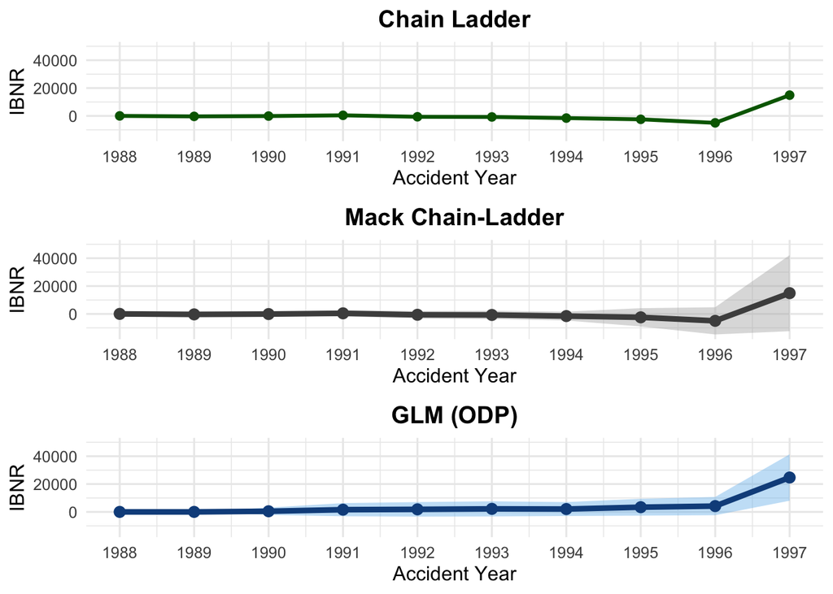

```r
library(knitr)

# Explicit accident years in the triangle
AYs <- 1988:1997

# Chain Ladder IBNR (already named by AY)
cl_ibnr <- as.numeric(cl_reserve[as.character(AYs)])

# Mack IBNR: your printed output shows 10 values in the same order as CL
mack_ibnr <- as.numeric(mack_reserve)          # length 10, 1988–1997 in order

# Mack SE by AY
mack_se <- as.numeric(mack_byorigin[as.character(AYs), "Mack.S.E"])
# mack_se
# GLM IBNR: glm_reserve has 9 values (for 1989–1997); pad 1988 with 0
glm_ibnr <- c(
  `1988` = 0,
  setNames(glm_reserve, as.character(1989:1997))
)
glm_se <- c(
  `1988` = 0,
  setNames(glm_ay_se, as.character(1989:1997))
)
# Make sure GLM is ordered 1988–1997
glm_ibnr <- as.numeric(glm_ibnr[as.character(AYs)])
glm_se <- as.numeric(glm_se[as.character(AYs)])
# Build main table
ay_compare <- data.frame(
  AY        = AYs,
  CL_IBNR   = cl_ibnr,
  Mack_IBNR = mack_ibnr,
  Mack_SE= mack_se,
  GLM_IBNR  = glm_ibnr,
  GLM_SE = glm_se
)

# Add total row
ay_compare <- rbind(
  ay_compare,
  data.frame(
    AY        = "Total",
    CL_IBNR   = sum(ay_compare$CL_IBNR,   na.rm = TRUE),
    Mack_IBNR = sum(ay_compare$Mack_IBNR, na.rm = TRUE),
    Mack_SE= sum(ay_compare$mack_se, na.rm = TRUE),
    GLM_IBNR  = glm_total_reserve,
    GLM_SE = glm_total_se
  )
)

# kable(
#   ay_compare,
#   caption = "Accident year and total IBNR comparison across Chain Ladder, Mack, and GLM"
# )
library(ggplot2)
library(gridExtra)

# Filter only accident years (no Total row)
plot_df <- subset(ay_compare, AY != "Total")
plot_df$AY_num <- as.numeric(as.character(plot_df$AY))

# y-axis limit
ylow  <- -15000
yhigh <- 50000

### 1) Chain Ladder (no band)
p_cl <- ggplot(plot_df, aes(x = AY_num, y = CL_IBNR)) +
  geom_line(size=1.1, color="darkgreen") +
  geom_point(size=2, color="darkgreen") +
  ylim(ylow, yhigh) +
  scale_x_continuous(breaks = plot_df$AY_num) +
  labs(title="Chain Ladder", x="Accident Year", y="IBNR") +
  theme_minimal(base_size=12) +
  theme(plot.title = element_text(face="bold", hjust=0.5))

### 2) Mack (band + line)
p_mack <- ggplot(plot_df, aes(x=AY_num, y=Mack_IBNR)) +
  geom_ribbon(aes(
      ymin = Mack_IBNR -  Mack_SE,
      ymax = Mack_IBNR +  Mack_SE),
      fill = "grey70", alpha = 0.45) +         # <–– visible band
  geom_line(size = 1.6, color="grey30") +      # thicker line on top
  geom_point(size = 2.7, color="grey30") +
  ylim(ylow, yhigh) +
  scale_x_continuous(breaks = plot_df$AY_num) +
  labs(title="Mack Chain-Ladder", x="Accident Year", y="IBNR") +
  theme_minimal(base_size=12) +
  theme(plot.title=element_text(face="bold",hjust=0.5))


### 3) GLM (band + line)
p_glm <- ggplot(plot_df, aes(x=AY_num, y=GLM_IBNR)) +
  geom_ribbon(aes(
      ymin = GLM_IBNR - GLM_SE,
      ymax = GLM_IBNR +  GLM_SE),
      fill = "skyblue2", alpha = 0.45) +       # visible band like example
  geom_line(size = 1.6, color="dodgerblue4") +
  geom_point(size = 2.7, color="dodgerblue4") +
  ylim(ylow, yhigh) +
  scale_x_continuous(breaks = plot_df$AY_num) +
  labs(title="GLM (ODP)", x="Accident Year", y="IBNR") +
  theme_minimal(base_size=12) +
  theme(plot.title=element_text(face="bold",hjust=0.5))

# Arrange 3 plots horizontally (1x3 layout)
grid.arrange(p_cl, p_mack, p_glm, nrow=3)
```

Figure 10: Accident-year IBNR comparison (CL, Mack, GLM)

# 6 Discussion

The three reserving approaches give meaningfully different outcomes. Chain Ladder and Mack both produce a very small total IBNR (~4400), suggesting the portfolio is largely run-off with minimal expected future emergence. However, Mack’s wide 95% interval (−58000 to 67000) and the GLM’s higher reserve estimate (~40000) highlight material tail uncertainty, particularly driven by AY 1997. In practice, when models diverge this way, decision-makers often rely on a more conservative upper-level reserve such as the stochastic or GLM indication rather than the deterministic Chain Ladder point estimate, to avoid under-reserving in the presence of uncertainty.

These results imply that while historical development appears stable, the last accident year remains the key source of risk. Model differences remind us that reserve estimates depend heavily on assumptions and data maturity. Thus, reserving decisions should also consider expert judgment, exposure changes, and business context beyond the numerical outputs alone.

# 7 Conclusion

# 8 Future Work

Future work could expand to multiple companies, paid triangles, or calendar-year effects to validate generality and reduce potential bias from using a single insurer.

# 9 Reference

Brown, R. L., & Gottlieb, L. R. (2007). Introduction to ratemaking and loss reserving for property and casualty insurance. Actex Publications.

Casualty Actuarial Society. (2011). Loss reserving data pulled from NAIC Schedule P. https://www.casact.org/publications-research/research/research-resources/loss-reserving-data-pulled-naic-schedule-p

# 10 Supplimentary Materials

This table data used for Accident-year IBNR comparison (CL, Mack, GLM) comparison plot. Table i: Accident-year IBNR comparison (CL, Mack, GLM)

```r
library(knitr)

# Explicit accident years in the triangle
AYs <- 1988:1997

# Chain Ladder IBNR (already named by AY)
cl_ibnr <- as.numeric(cl_reserve[as.character(AYs)])

# Mack IBNR: your printed output shows 10 values in the same order as CL
mack_ibnr <- as.numeric(mack_reserve)          # length 10, 1988–1997 in order

# Mack SE by AY
mack_se <- as.numeric(mack_byorigin[as.character(AYs), "Mack.S.E"])
# mack_se
# GLM IBNR: glm_reserve has 9 values (for 1989–1997); pad 1988 with 0
glm_ibnr <- c(
  `1988` = 0,
  setNames(glm_reserve, as.character(1989:1997))
)
glm_se <- c(
  `1988` = 0,
  setNames(glm_ay_se, as.character(1989:1997))
)
# Make sure GLM is ordered 1988–1997
glm_ibnr <- as.numeric(glm_ibnr[as.character(AYs)])
glm_se <- as.numeric(glm_se[as.character(AYs)])
# Build main table
ay_compare <- data.frame(
  AY        = AYs,
  CL_IBNR   = cl_ibnr,
  Mack_IBNR = mack_ibnr,
  Mack_SE= mack_se,
  GLM_IBNR  = glm_ibnr,
  GLM_SE = glm_se
)

# Add total row
ay_compare <- rbind(
  ay_compare,
  data.frame(
    AY        = "Total",
    CL_IBNR   = sum(ay_compare$CL_IBNR,   na.rm = TRUE),
    Mack_IBNR = sum(ay_compare$Mack_IBNR, na.rm = TRUE),
    Mack_SE= sum(ay_compare$mack_se, na.rm = TRUE),
    GLM_IBNR  = glm_total_reserve,
    GLM_SE = glm_total_se
  )
)

kable(
  ay_compare,
  caption = "Accident year and total IBNR comparison across Chain Ladder, Mack, and GLM"
)
```

Accident year and total IBNR comparison across Chain Ladder, Mack, and GLM

[output not shown]